# Local Polynomial Regression

## Loading the Data

```r
# Read in the data
solarAU <- read_csv(
  file="solarAU.csv",
  col_types = cols(
    X1=col_integer(),
    prod=col_double(),
    toy=col_double(),
    tod=col_double()
  ))
# Work with log production, since it's less skewed
solarAU$logprod <- log(solarAU$prod+0.01)  # +0.01 to avoid -Inf when production is 0
```

## Plotting the Data

We can plot the log production as a function of the time of the year and the time of the day.

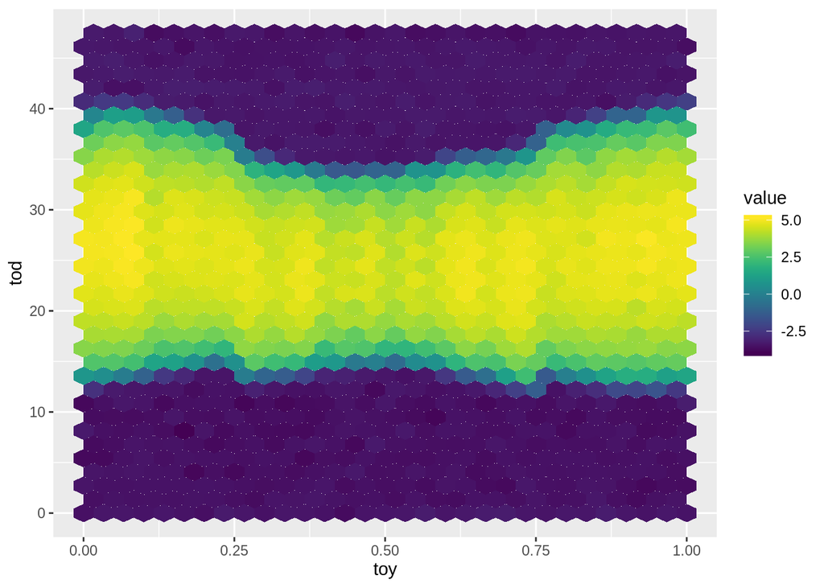

## Question 1 - Linear Regression Model

We want to model $\mathbb{E}[y \mid \boldsymbol{x}]$ as a polunomial regression model. We basically want to solve the following minimization problem
$$\widehat{\beta} = \arg\min_{\beta}\parallel \boldsymbol{y} - \boldsymbol{X}\beta\parallel^2$$
where the model matrix is given by

```r
X <- with(solarAU, cbind(1, tod, tod^2, toy, toy^2))
y <- solarAU$logprod
colnames(X) <- c("intercept", "tod", "todsq", "toy", "toysq")
```

Cholesky decomposition of a matrix $\Sigma$ can be thought of as the “matrix square root” $R$ so that $R\top R = \Sigma$. In `R` this can be found using the `chol()` function, which returns the **upper triangular** square root matrix of any positive definite matrix, this is called **Cholesky factor**. Cholesky decomposition requires $\frac{n^3}{3}$ FLOPS and $n$ square roots.

The QR decomposition decomposes a $r\times c$ rectangular matrix $\boldsymbol{X}$ (with $r \geq c$) as the product of an upper triangular matrix $R$ and of an orthogonal matrix $Q$ (i.e. with $Q^\top Q = I$), so that $X = QR$. The computational cost of the QR decomposition is $\mathcal{O}(rc^2)$. Notice that the minimization problem above is solved by
$$\widehat{\beta} = (\boldsymbol{X}^\top \boldsymbol{X})\boldsymbol{X}\boldsymbol{y}$$
Using the QR decomposition we can rewrite this expression for $\widehat{\beta}$ as follows

$$\begin{align}
(\boldsymbol{\mathbf{X}}^\top \boldsymbol{\mathbf{X}})\boldsymbol{\mathbf{X}}^\top \boldsymbol{\mathbf{y}}&= (\boldsymbol{\mathbf{R}}^\top \boldsymbol{\mathbf{Q}}^\top \boldsymbol{\mathbf{Q}}\boldsymbol{\mathbf{R}})^{-1} \boldsymbol{\mathbf{R}}^\top \boldsymbol{\mathbf{Q}}^\top \boldsymbol{\mathbf{y}}\\
&= (\boldsymbol{\mathbf{R}}^\top \boldsymbol{\mathbf{R}})^{-1} \boldsymbol{\mathbf{R}}^\top \boldsymbol{\mathbf{Q}}^\top \boldsymbol{\mathbf{y}}\\
&= \boldsymbol{\mathbf{R}}^{-1}\boldsymbol{\mathbf{R}}^{-\top}\boldsymbol{\mathbf{R}}^\top \boldsymbol{\mathbf{Q}}^\top \boldsymbol{\mathbf{y}}\\
&= \boldsymbol{\mathbf{R}}^{-1}\boldsymbol{\mathbf{Q}}^\top \boldsymbol{\mathbf{y}}
\end{align}$$

The connection between the QR decomposition and the Cholesky decomposition is that if $\boldsymbol{\mathbf{X}}= \boldsymbol{\mathbf{R}}\boldsymbol{\mathbf{Q}}$ then $\boldsymbol{\mathbf{X}}^\top \boldsymbol{\mathbf{X}}= \boldsymbol{\mathbf{R}}^\top \boldsymbol{\mathbf{R}}$ so that the QR decomposition of $\boldsymbol{\mathbf{X}}$ gives the cholesky factorization of $\boldsymbol{\mathbf{X}}^\top\boldsymbol{\mathbf{X}}$ for free.

### Q`R` Solutions

First, we solve the system using the `lm` routine from `R`.

```r
# Fit the model to log production
lm_fit <- function(data){
  return(lm(logprod ~ tod + I(tod^2) + toy + I(toy^2), data=data))
}
fit <- lm_fit(solarAU)
```

We can also solve the system using the `QR` decomposition using the formula derived above. Notice that there’s multiple ways of doing this:

- `qr.solve(A, b)` solves a system of equations $Ax = b$ via the QR decomposition. If `A` is a rectangular matrix, `qr.solve` will find its `QR` decomposition and then solve the system of equations. If, instead, `A` is a QR decomposition object this just uses it to solve the system.
- `solve.qr(A, b)` Basically solve a system using fields and methods of the `QR` object.
- `qr` to find the `qr` decomposition and then solving it using `solve.qr()`. Notice that this is equivalent to `qr.solve()`.

```r
# QR + solve.qr = qr.solve
qr_solve <- function(){
  return(qr.solve(X, solarAU$logprod))
}
# Manual QR + solve
qr_solve_manual <- function(){
  # find qr decomposition
  qr_obj <- qr(X)
  # Use it with solve
  return(backsolve(qr.R(qr_obj), t(qr.Q(qr_obj)) %*% solarAU$logprod))
}
# Using solve.qr with a qr decomposition
solve_qr <- function(){
  # find qr object
  qr_obj <- qr(X)
  # solve it with solve.qr()
  return(solve.qr(qr_obj, solarAU$logprod))
}
# Microbenchmark them
microbenchmark(qr_solve=qr_solve(),
               manual=qr_solve_manual(),
               solve_qr=solve_qr(),
               unit="relative")
```

```
## Unit: relative
##      expr      min       lq     mean   median       uq       max neval
##  qr_solve 0.951018 1.015110 1.040268 1.000303 1.013258 1.0090466   100
##    manual 2.008418 2.075721 1.496579 1.977464 2.152030 0.1528857   100
##  solve_qr 1.000000 1.000000 1.000000 1.000000 1.000000 1.0000000   100
```

```r
qr_solve_result <- qr_solve()
qr_solve_manual_result <- qr_solve_manual()
solve_qr_result <- solve_qr()
one_and_two <- max(abs(qr_solve_result - qr_solve_manual_result))
one_and_three <- max(abs(qr_solve_result - solve_qr_result))
two_and_three <- max(abs(qr_solve_manual_result - solve_qr_result))
lm_and_one <- max(abs(fit$coefficients - qr_solve_result))
cat("Maximum difference between qr.solve() and manual QR solve: ", one_and_two, "\n",
    "Maximum difference between qr.solve() and solve.qr(): ", one_and_three, "\n",
    "Maximum difference between manual QR solve and solve.qr(): ", two_and_three, "\n",
    "Maximum difference between lm() and qr.solve(): ", lm_and_one)
```

```
## Maximum difference between qr.solve() and manual QR solve:  7.371881e-14
##  Maximum difference between qr.solve() and solve.qr():  0
##  Maximum difference between manual QR solve and solve.qr():  7.371881e-14
##  Maximum difference between lm() and qr.solve():  0
```

```r
# Add a column to solarAU containing the fitted values
solarAU$fitPoly <- fit$fitted.values
# Plot the fitted values
pl1 <- ggplot(solarAU,
              aes(x = toy, y = tod, z = fitPoly)) +
       stat_summary_hex() +
       scale_fill_gradientn(colours = viridis(50))
# Plot the difference between fitted values and log production
pl2 <- ggplot(solarAU,
              aes(x = toy, y = tod, z = logprod - fitPoly)) +
       stat_summary_hex() +
       scale_fill_gradientn(colours = viridis(50))
grid.arrange(pl1, pl2, ncol = 2)
```

[output not shown]

### Cholesky Solutions in R

We can also use Cholesky decomposition to solve the same system of equations.

```r
cholesky_solver <- function(){
  L <- chol(crossprod(X))
  return(backsolve(L, forwardsolve(t(L), t(X) %*% solarAU$logprod)))
}
chol_result <- cholesky_solver()
```

We can check that we do get the same result as the QR decomposition

```r
max(abs(chol_result - qr_solve_result))
```

```
## [1] 8.415491e-12
```

Finally, we can benchmark the Cholesky solver against the QR solver

```r
microbenchmark(
  chol=cholesky_solver(),
  qr=qr_solve(),
  unit="relative",
  times=500
)
```

```
## Unit: relative
##  expr      min      lq    mean  median      uq      max neval
##  chol 1.000000 1.00000 1.00000 1.00000 1.00000 1.000000   500
##    qr 1.050276 1.09403 1.82676 1.06397 1.14011 1.025002   500
```

We can see that the Cholesky decomposition is indeed faster.

## Comparing QR and Cholesky between R and Rcpp

```r
sourceCpp("cppattempt.cpp")
microbenchmark(
  RChol=cholesky_solver(),
  RcppChol=choleskySolverArmadillo(X, y),
  R_QR=qr_solve(),
  RcppQR=qrSolverArmadillo(X, y),
  unit="relative"
)
```

```
## Unit: relative
##      expr      min       lq     mean   median       uq       max neval
##     RChol 2.496849 2.565135 3.627916 2.545425 2.340374 34.199186   100
##  RcppChol 1.000000 1.000000 1.000000 1.000000 1.000000  1.000000   100
##      R_QR 2.649697 2.917328 4.438782 2.863632 3.136457 41.421663   100
##    RcppQR 2.139692 2.212617 2.108389 2.177204 1.990869  2.061108   100
```

## Question 2 - R

```r
library(mvtnorm)
lmLocal <- function(y, x0, X0, x, X, H){
  w <- dmvnorm(x, x0, H)
  fit <- lm(y ~ -1 + X, weights = w)
  return( t(X0) %*% coef(fit) )
}
```

This has to be done for all rows of $X$. Instead we only do it on a subset of $2000$ rows.

```r
n <- nrow(X)
nsub <- 2e3
sub <- sample(1:n, nsub, replace = FALSE)

y <- solarAU$logprod
solarAU_sub <- solarAU[sub, ]
x <- as.matrix(solarAU[c("tod", "toy")])
x0 <- x[sub, ]
X0 <- X[sub, ]
```

Now we compute estimates at each subsampled location

```r
predLocal <- sapply(1:nsub, function(ii){
  lmLocal(y = y, x0 = x0[ii, ], X0 = X0[ii, ], x = x, X = X, H = diag(c(1, 0.1)^2))
})
```

Look at the fit

```r
solarAU_sub$fitLocal <- predLocal
```

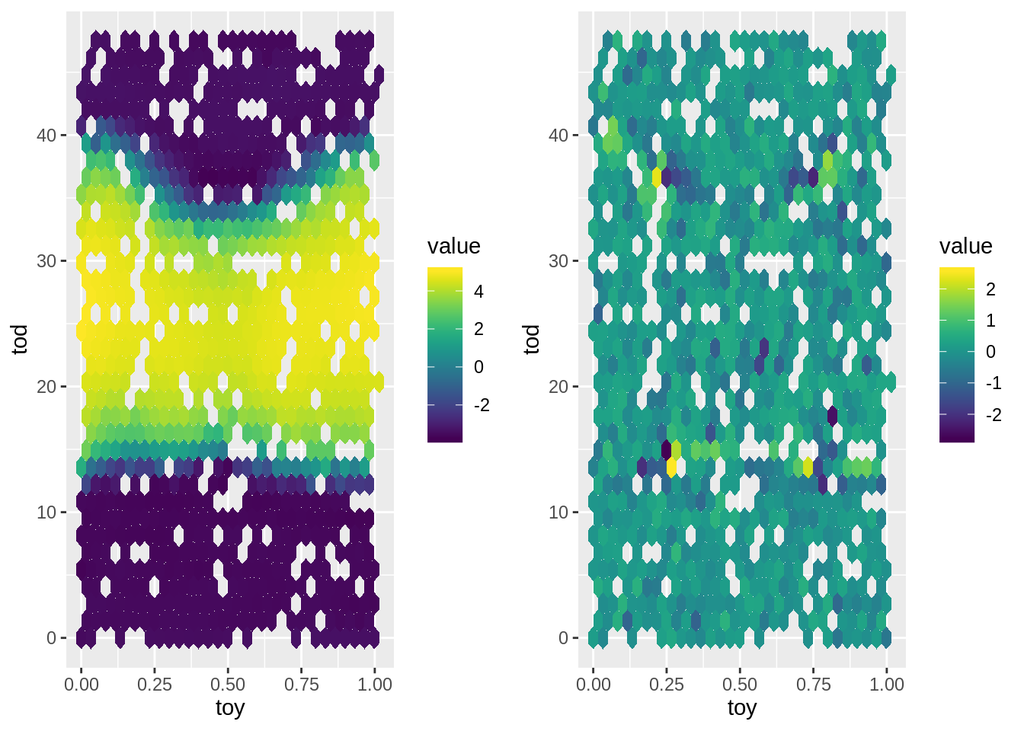

```r
pl1 <- ggplot(solarAU_sub,
       aes(x = toy, y = tod, z = fitLocal)) +
       stat_summary_hex() +
       scale_fill_gradientn(colours = viridis(50))

pl2 <- ggplot(solarAU_sub,
       aes(x = toy, y = tod, z = logprod - fitLocal)) +
       stat_summary_hex() +
       scale_fill_gradientn(colours = viridis(50))

grid.arrange(pl1, pl2, ncol = 2)
```

## Question 2 in Rcpp